# Correlation

### Is there an associate between body mass and flipper length?

Just to demonstrate a two-tailed test, let’s test the following hypotheses:

$\rho:$ the population correlation coefficient between `body_mass` and `flipper_length_mm`.

$H_0: \rho = 0$

$H_1: \rho \neq 0$.

Visual and summary:

```r
penguins_complete %>%
    summarise(sample_size = n(),
              corr = cor(body_mass_g, flipper_length_mm))
```

| sample_size | corr |
| --- | --- |
| 333 | 0.8729789 |

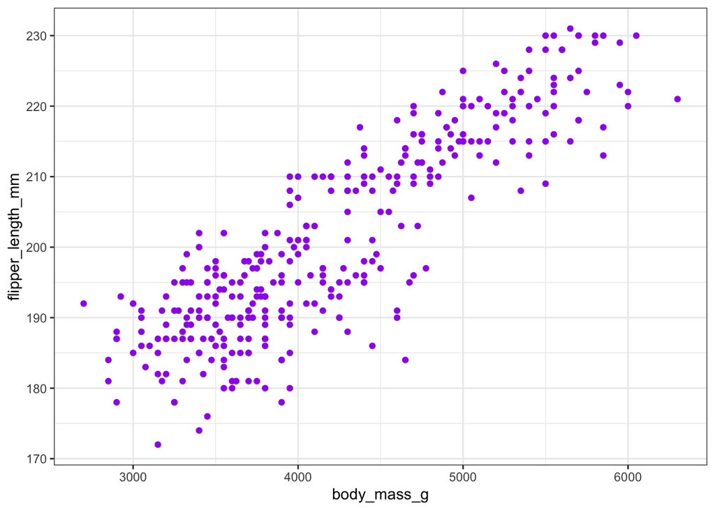

```r
penguins_complete %>%
    ggplot(data = .,
            aes(x = body_mass_g, flipper_length_mm))+
    geom_point(color='purple') +
    theme_bw()
```

Let’s run our hypothesis test:

```r
penguins_complete %>%
    with(
        cor.test(body_mass_g, flipper_length_mm)
    ) %>% tidy() %>% select(estimate,p.value)
```

| estimate | p.value |
| --- | --- |
| 0.8729789 | 3.132836e-105 |

Our $P$-value is well below a standard significance level of 0.05, so we have evidence to suggest there is a correlation between body mass and flipper length for penguins.

### Follow-up questions (for those interested…)

**Q:** Which relationship is stronger, flipper length with bill length, or flipper length with body mass?

Without doing something more complicated, we could look at confidence interval estimates for each correlation coefficient and try to compare:

```r
penguins_complete %>%
    with(
        cor.test(bill_length_mm, flipper_length_mm)
    ) %>% tidy() %>% select(conf.low, conf.high)
```

| conf.low | conf.high |
| --- | --- |
| 0.5868092 | 0.7106869 |

```r
penguins_complete %>%
    with(
        cor.test(body_mass_g, flipper_length_mm)
    ) %>% tidy() %>% select(conf.low, conf.high)
```

| conf.low | conf.high |
| --- | --- |
| 0.8447622 | 0.896355 |

Notice that these confidence intervals do not overlap at all!

- The highest estimated correlation coefficient for bill length and flipper length is 0.71, while the *lowest* estimated correlation coefficient for body mass and flipper length is 0.844.
- This suggests that at the population level, the relationship between body mass and flipper length is the stronger one.

**Q:** What if we consider the species in this analysis?

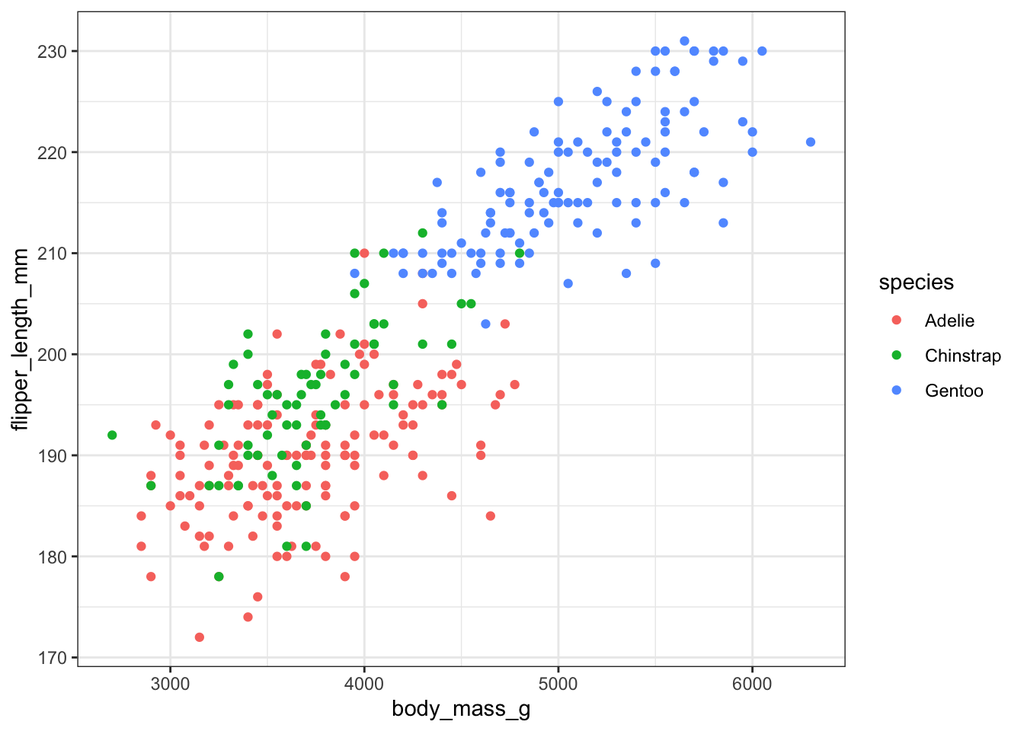

```r
penguins_complete %>%
    ggplot(data = .,
            aes(x = body_mass_g, flipper_length_mm, color = species))+
    geom_point() +
    theme_bw()
```

```r
penguins_complete %>%
    group_by(species) %>%
    summarise(sample_size = n(),
              corr = cor(body_mass_g,flipper_length_mm)
              )
```

| species | sample_size | corr |
| --- | --- | --- |
| Adelie | 146 | 0.4648539 |
| Chinstrap | 68 | 0.6415594 |
| Gentoo | 119 | 0.7113053 |

The visual and summary table suggest that, at least on the data, this relationship has varying strength for different species. We would have to do some inference for this to make any claims about the population trend, but that would require techniques beyond this course!